# Deep 7 Shark Depredation Investigation

Meg Oshima

10/21/2021

## Data structure

```
##     tripID             trip_beg             trip_end              fyear
##  Length:143108      Min.   :2002-09-28   Min.   :2002-10-01   Min.   :2003
##  Class :character   1st Qu.:2012-04-06   1st Qu.:2012-04-06   1st Qu.:2008
##  Mode  :character   Median :2014-12-01   Median :2014-12-01   Median :2012
##                     Mean   :2014-12-15   Mean   :2014-12-15   Mean   :2012
##                     3rd Qu.:2017-10-29   3rd Qu.:2017-10-29   3rd Qu.:2016
##                     Max.   :2021-06-30   Max.   :2021-06-30   Max.   :2021
##                     NA's   :52345        NA's   :52345
##    port_dprtr       port_land     chartered    wind_speed
##         :111862   117    :18917   0:141085   Min.   : 0.00
##  117    :  4159   501    :18011   1:  2023   1st Qu.:10.00
##  501    :  3961   152    :11151              Median :15.00
##  152    :  3051   222    : 9838              Mean   :12.96
##  221    :  2087   221    : 8765              3rd Qu.:18.00
##  222    :  2078   512    : 6331              Max.   :30.00
##  (Other): 15910   (Other):70095              NA's   :142371
##      buoy                area         subarea            depth_beg
##  Length:143108      Min.   :100.0   Length:143108      Min.   :  0.00
##  Class :character   1st Qu.:122.0   Class :character   1st Qu.: 60.00
##  Mode  :character   Median :320.0   Mode  :character   Median : 70.00
##                     Mean   :281.8                      Mean   : 71.39
##                     3rd Qu.:331.0                      3rd Qu.: 80.00
##                     Max.   :594.0                      Max.   :130.00
##                                                        NA's   :142371
##    depth_end         fname                gear            hours
##  Min.   :  0.0    Length:143108      3      :125245   Min.   :  0.080
##  1st Qu.: 80.0    Class :character   4      :  6275   1st Qu.:  5.000
##  Median :100.0    Mode  :character   9      :  4065   Median :  7.000
##  Mean   :102.5                       62     :  2525   Mean   :  7.939
##  3rd Qu.:130.0                       10     :  2263   3rd Qu.:  9.000
##  Max.   :160.0                       61     :  1161   Max.   :336.000
##  NA's   :142371                      (Other):  1574   NA's   :210
##      hooks           SPECIES          caught             lbs
##  Min.   : 1       Min.   :15.00   Min.   :  0.000   Min.   :   0.00
##  1st Qu.: 2       1st Qu.:19.00   1st Qu.:  2.000   1st Qu.:   7.00
##  Median : 5       Median :20.00   Median :  4.000   Median :  17.00
##  Mean   : 4       Mean   :25.62   Mean   :  9.659   Mean   :  41.84
##  3rd Qu.: 5       3rd Qu.:22.00   3rd Qu.: 11.000   3rd Qu.:  44.00
##  Max.   :10       Max.   :97.00   Max.   :557.000   Max.   :3296.00
##  NA's   :139427                   NA's   :109       NA's   :226
```

[output cut: 25 more lines]

```
##  Min.   : NA      Length:143108      Min.   : 4.00   Length:143108
##  1st Qu.: NA      Class :character   1st Qu.: 7.00   Class :character
##  Median : NA      Mode  :character   Median :13.00   Mode  :character
##  Mean   :NaN                         Mean   :11.62
##  3rd Qu.: NA                         3rd Qu.:14.00
##  Max.   : NA                         Max.   :17.00
##  NA's   :143108
##    CAT_B1_ORD    FAD_SP              NAME              Sp_Cat
##  Min.   :4    Length:143108      Length:143108      Length:143108
##  1st Qu.:4    Class :character   Class :character   Class :character
##  Median :4    Mode  :character   Mode  :character   Mode  :character
##  Mean   :4
##  3rd Qu.:4
##  Max.   :4
##
```

## QA/QC

Some issues within the dataset are:

- instances of catch = 0, number_lost_to_predator = 0, and released = 0, but weight != 0. **Recommend removing these records**

| fished | Sp | caught | number_lost_to_predator | release | lbs |
| --- | --- | --- | --- | --- | --- |
| 2002-10-29 | Opakapaka | 0 | 0 | 0 | 15.6 |
| 2002-11-03 | Lehi | 0 | 0 | 0 | 10.2 |
| 2002-11-23 | Onaga | 0 | 0 | 0 | 108.0 |
| 2002-12-21 | Opakapaka | 0 | 0 | 0 | 51.0 |
| 2003-01-07 | Opakapaka | 0 | 0 | 0 | 33.9 |
| 2003-01-09 | Opakapaka | 0 | 0 | 0 | 59.5 |

- instances of catch is NA but number_lost_to_predator and lbs > 0. Would this be cases of the fishermen guessing at the weight that the lost fish were? **Recommend removing these records unless more information is known.**

| tripID | Sp | caught | lbs | number_lost_to_predator | release | predator |
| --- | --- | --- | --- | --- | --- | --- |
| 23628_HA3419CF_2010-12-20 | Opakapaka | NA | 50 | 8 | 0 | Shark (Misc.) |
| 22540_2811_2010-12-24 | Opakapaka | NA | 150 | 20 | 0 | Shark (Misc.) |
| 21978_HA4613F_2012-01-18 | Opakapaka | NA | 100 | 10 | 0 | Unknown |

## Who is reporting depredation?

13% of all trips reported some loss of catch due to predators. Out of the 2390 unique fishing licenses, 170 have reported more than 10 instances with fish lost to predator over the entire time period and 38 fishers have reported more than 50 instances of fish lost to predator over the entire time period. The max number of reports by one license ID is 465 The mean number of trips with fish reported lost to predators is 376.79 trips per year.

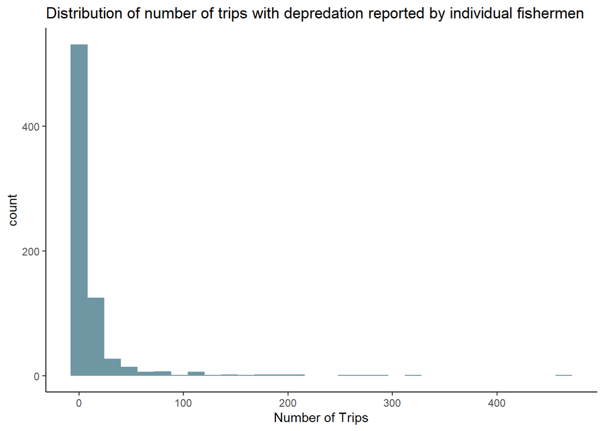

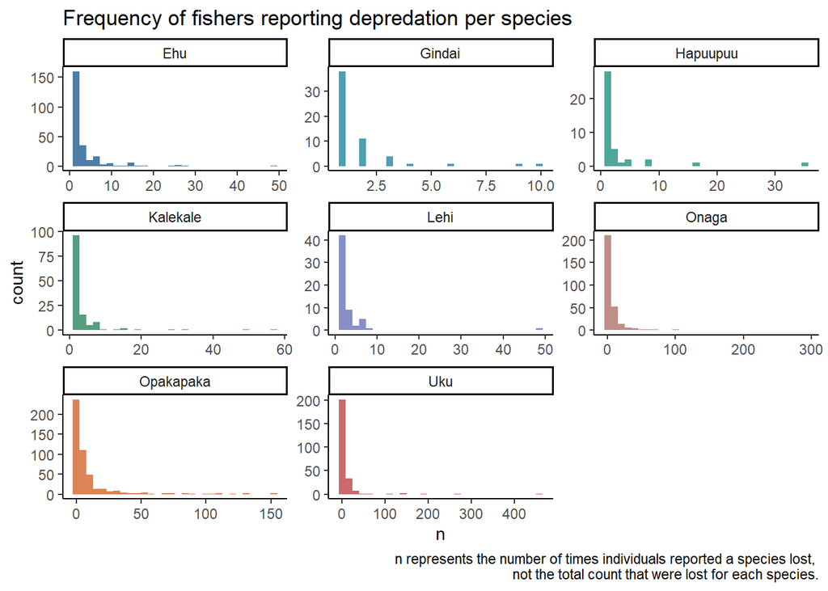

## Depredation Over Time

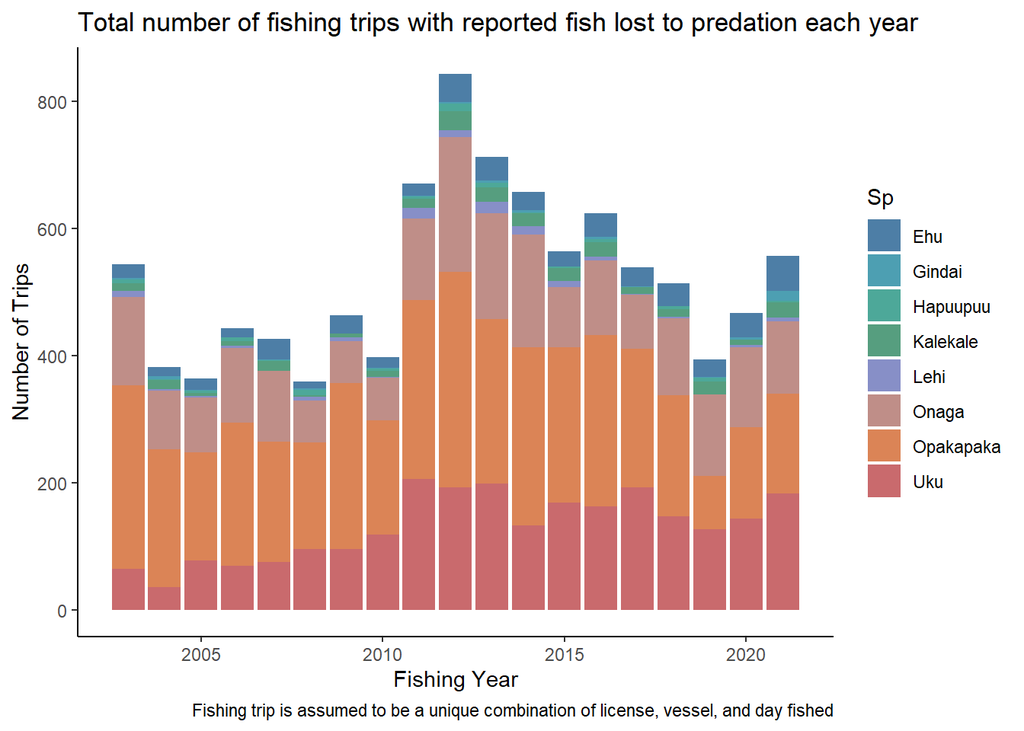

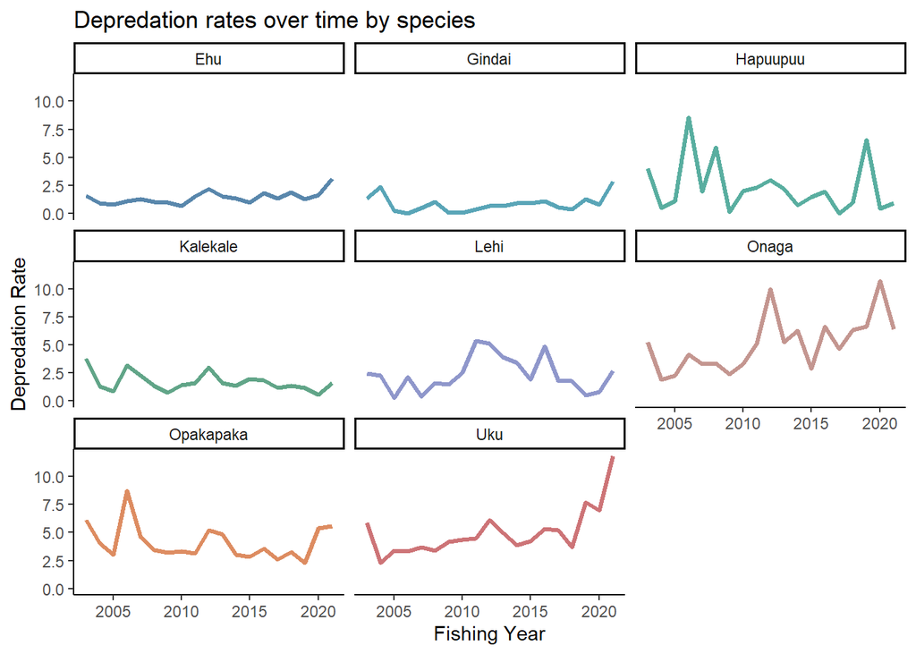

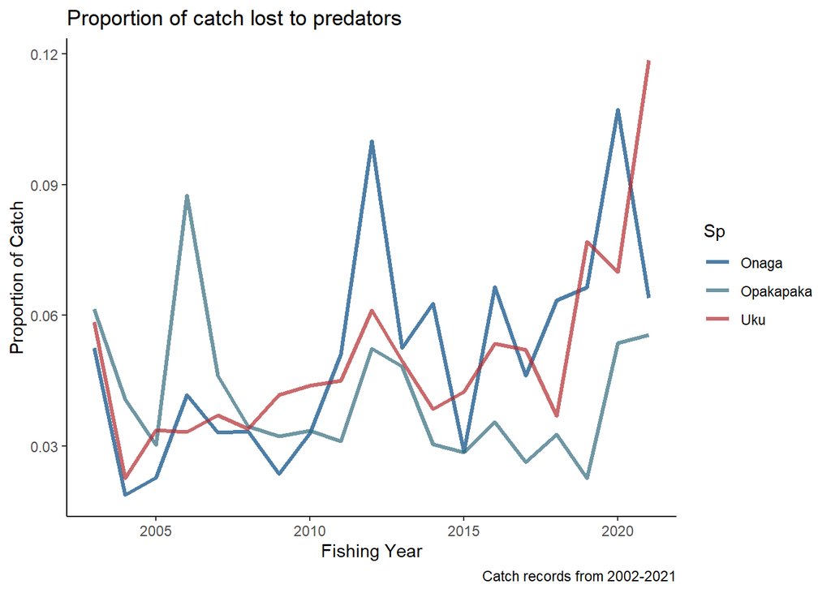

The proportion of catch lost to predators for the three main species that experience depredation (Opaka, Onaga, and Uku) is shown in the figure above. The proportion $P$ is calculated by $P = D_y/(D_y + C_y + R_y)$ where $D_y$ is the total number of fish per species lost to predators in year $y$, $C_y$ is the total number of fish per species caught in year $y$, and $R_y$ is the number released in year $y$. *Note: most release is 0 so there is minimal difference between including and excluding released but included it to be consistent with other studies.*

Total percent of catch lost to predation by species

| Species | Number Lost | Number Caught | Number Released | Percent Lost to Predation |
| --- | --- | --- | --- | --- |
| Uku | 10608 | 201868 | 1841 | 4.95 |
| Onaga | 11427 | 220856 | 1106 | 4.90 |
| Opakapaka | 23548 | 571602 | 9175 | 3.90 |
| Lehi | 533 | 21781 | 60 | 2.38 |
| Hapuupuu | 330 | 13880 | 34 | 2.32 |
| Kalekale | 1872 | 109912 | 992 | 1.66 |
| Ehu | 3205 | 215124 | 2017 | 1.45 |
| Gindai | 253 | 26134 | 99 | 0.96 |

## Depredation by Location

#### Is the majority of depredation occurring in Penguin Banks?

| Island | Total Lost | Total Caught | Total Released | Percent of Catch Lost |
| --- | --- | --- | --- | --- |
| Onaga |  |  |  |  |
| Penguin Bank | 4818 | 39489 | 56 | 10.86 |
| Hawaii | 2221 | 32572 | 92 | 6.37 |
| Kauai | 916 | 14561 | 220 | 5.84 |
| Offshore | 173 | 3683 | 1 | 4.49 |
| Oahu | 627 | 13735 | 112 | 4.33 |
| Maui Nui | 2672 | 116816 | 625 | 2.22 |
| Uku |  |  |  |  |
| Penguin Bank | 7008 | 76750 | 113 | 8.36 |
| Hawaii | 1344 | 30033 | 196 | 4.26 |
| Kauai | 1312 | 35619 | 844 | 3.47 |
| Oahu | 406 | 14776 | 91 | 2.66 |
| Offshore | 91 | 5517 | 31 | 1.61 |
| Maui Nui | 447 | 39173 | 566 | 1.11 |
| Opakapaka |  |  |  |  |
| Oahu | 4373 | 47436 | 573 | 8.35 |
| Kauai | 973 | 11190 | 224 | 7.86 |
| Hawaii | 8327 | 121911 | 1355 | 6.33 |
| Penguin Bank | 5231 | 81432 | 1549 | 5.93 |
| Offshore | 120 | 4066 | 20 | 2.85 |
| Maui Nui | 4524 | 305567 | 5454 | 1.43 |
| Lehi |  |  |  |  |
| Oahu | 31 | 455 | 0 | 6.38 |
| Hawaii | 469 | 15390 | 33 | 2.95 |
| Kauai | 3 | 271 | 0 | 1.09 |
| Penguin Bank | 6 | 559 | 0 | 1.06 |
| Offshore | 1 | 118 | 16 | 0.74 |
| Maui Nui | 23 | 4988 | 11 | 0.46 |
| Hapuupuu |  |  |  |  |
| Kauai | 207 | 3145 | 9 | 6.16 |
| Offshore | 26 | 766 | 0 | 3.28 |
| Oahu | 47 | 1867 | 2 | 2.45 |
| Penguin Bank | 11 | 916 | 2 | 1.18 |
| Hawaii | 28 | 4125 | 3 | 0.67 |
| Maui Nui | 11 | 3061 | 18 | 0.36 |
| Kalekale |  |  |  |  |
| Kauai | 426 | 14569 | 38 | 2.83 |
| Offshore | 27 | 1092 | 4 | 2.40 |
| Hawaii | 870 | 42880 | 204 | 1.98 |
| Oahu | 80 | 4603 | 26 | 1.70 |
| Penguin Bank | 226 | 18116 | 215 | 1.22 |
| Maui Nui | 243 | 28652 | 505 | 0.83 |
| Ehu |  |  |  |  |
| Penguin Bank | 984 | 38167 | 274 | 2.50 |
| Oahu | 383 | 15624 | 223 | 2.36 |
| Kauai | 743 | 30934 | 446 | 2.31 |
| Maui Nui | 531 | 58496 | 637 | 0.89 |
| Offshore | 10 | 1203 | 8 | 0.82 |
| Hawaii | 554 | 70700 | 429 | 0.77 |
| Gindai |  |  |  |  |
| Penguin Bank | 54 | 3333 | 1 | 1.59 |
| Oahu | 26 | 1689 | 8 | 1.51 |
| Kauai | 110 | 7504 | 34 | 1.44 |
| Hawaii | 59 | 11673 | 49 | 0.50 |
| Offshore | 1 | 242 | 1 | 0.41 |
| Maui Nui | 3 | 1693 | 6 | 0.18 |

Spatial trends are not consistent among species. For Onaga and Uku, the highest percent of catch lost to depredation (11% and 8% respectively) is at Penguin Banks area but for Opakapaka and Lehi, the highest depredation is off Ohau (8% and 6% respectively). Ehu and Gindai also experience the highest depredation rates at Penguin Banks (2.5% and 1.6% respectively), and Hapuupuu and Kalekale experience highest depredation rates off Kauai.

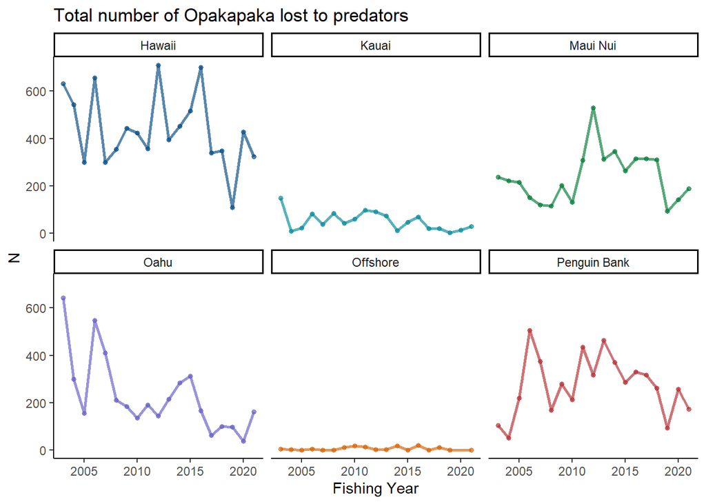

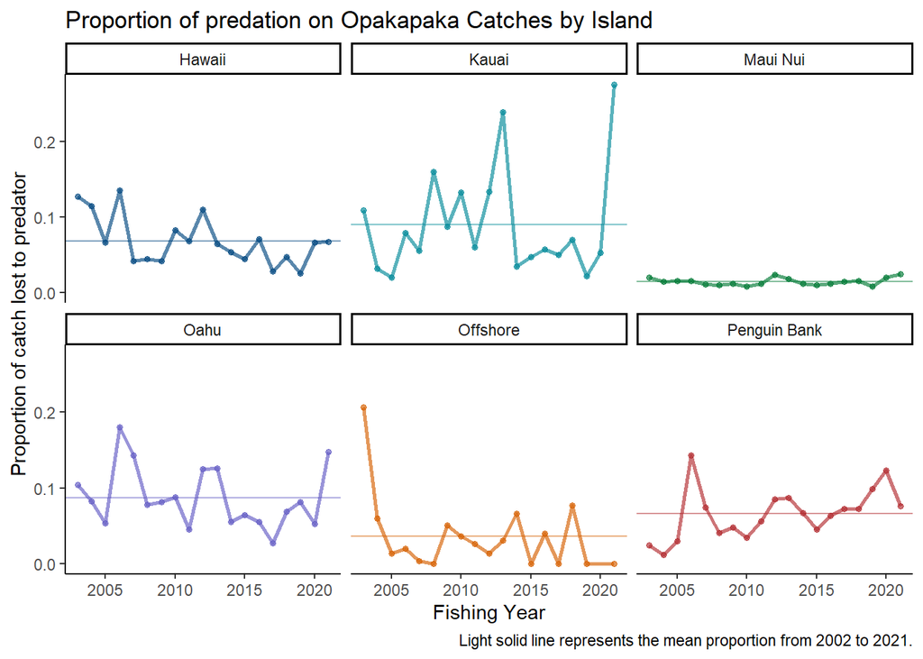

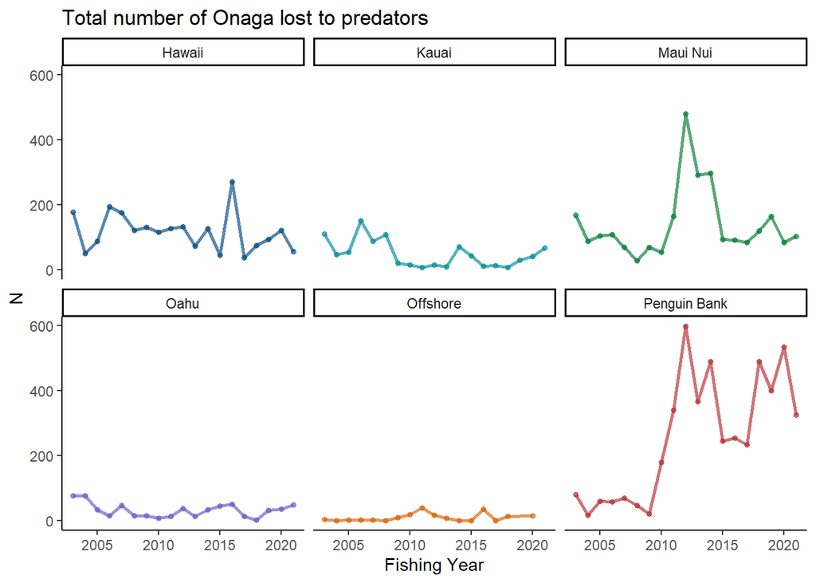

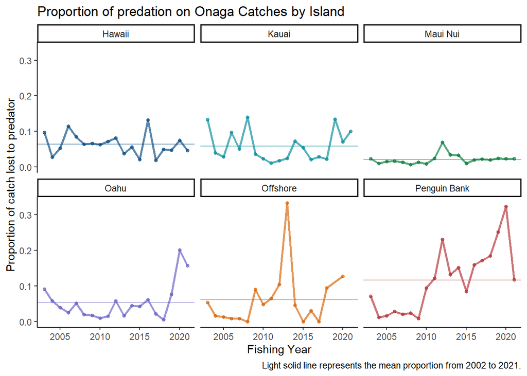

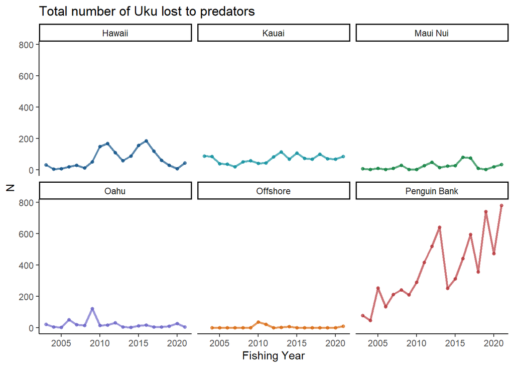

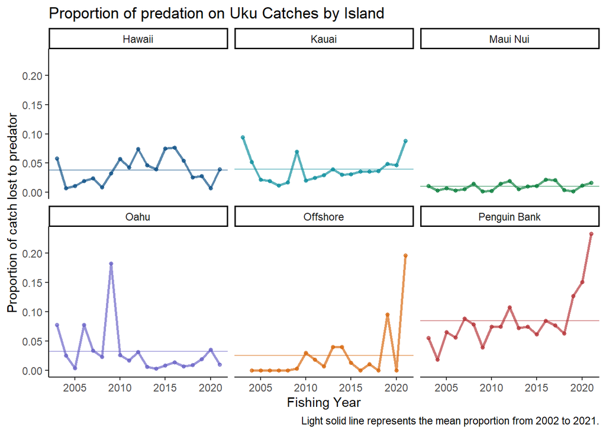

## Depredation by Trip Attributes

#### Gear Type

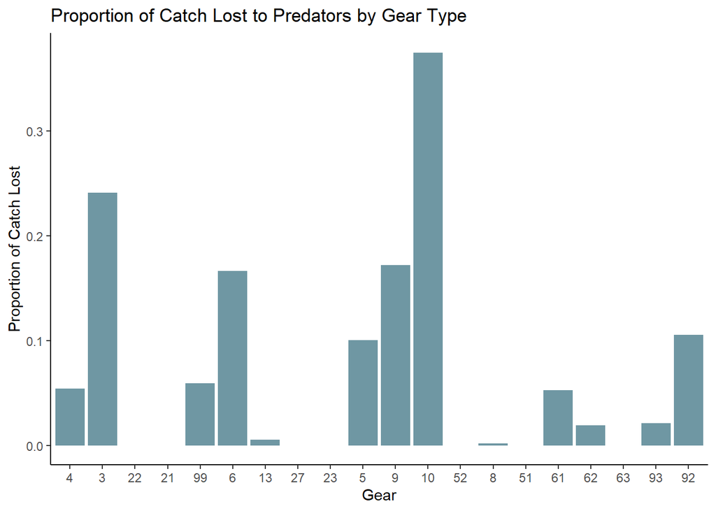

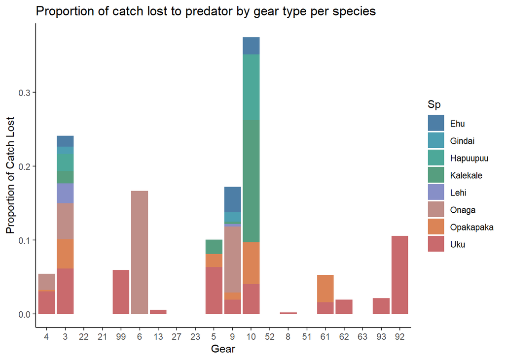

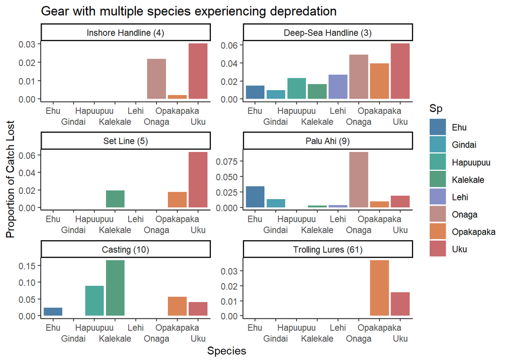

Gear types 3 (deep-sea handline), 6 (trolling), 9 (Palu Ahi, tuna handline), and 10 (casting) have the highest proportions of catch lost to predators. For gear 6, there were 5 individual fishing trips recorded using that gear type in 2003 (n = 1) and 2004 (n = 4). The species caught on those trips with gear 6 included Onaga (n = 5), Uku (n = 3), and Lehi (n = 2) and with only 1 Onaga reported as lost to a predator. Gear type 3 is the most commonly used and catches were highest for this gear for all species. With gear 9, Uku, Opakapaka, and Lehi catches were highest (n = 4389, n = 3772, and n = 2779 respectively) but Onaga had the highest proportion of catch lost to predators (prop_dep = 0.0897). Gear 10 caught Ehu, Gindai, Hapuupuu, Kalekale, Lehi, Onaga, Opakapaka, Uku with the majority being Uku. The species that experienced the highest proportion of catch lost to depredation was Kalekale, with 539 fish lost to a predator. With gear 10, the proportion of Uku catch lost to predators was 0.0406.

#### Depth

For all instances where depth (beginning [blue dots] or ending [red dots]) was recorded, there were no records of fish being lost to predators.

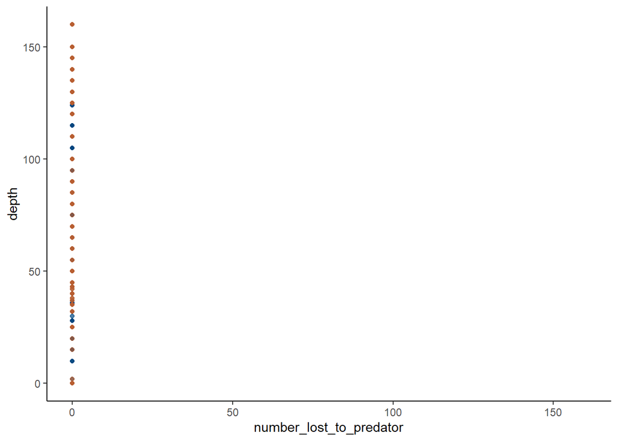

#### Wind Speed

For all instances where wind speed was recorded, there were no records of fish being lost to predators.

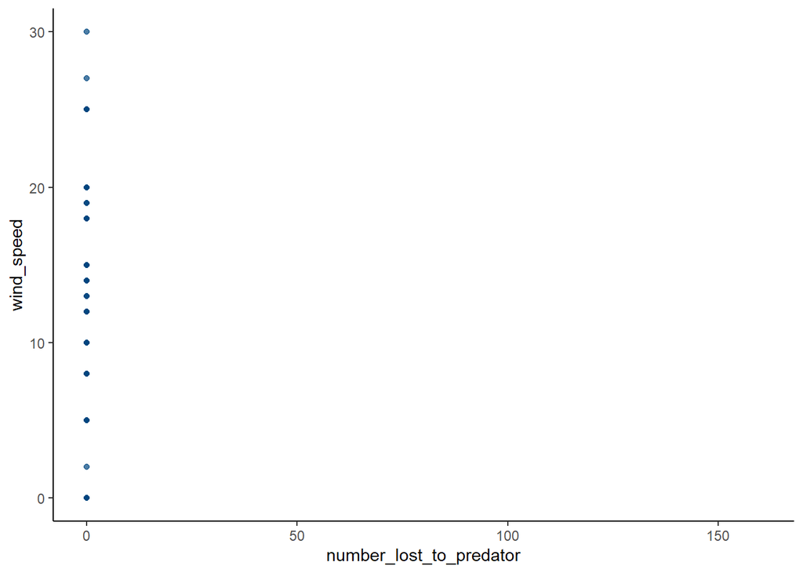

#### Hours Fished

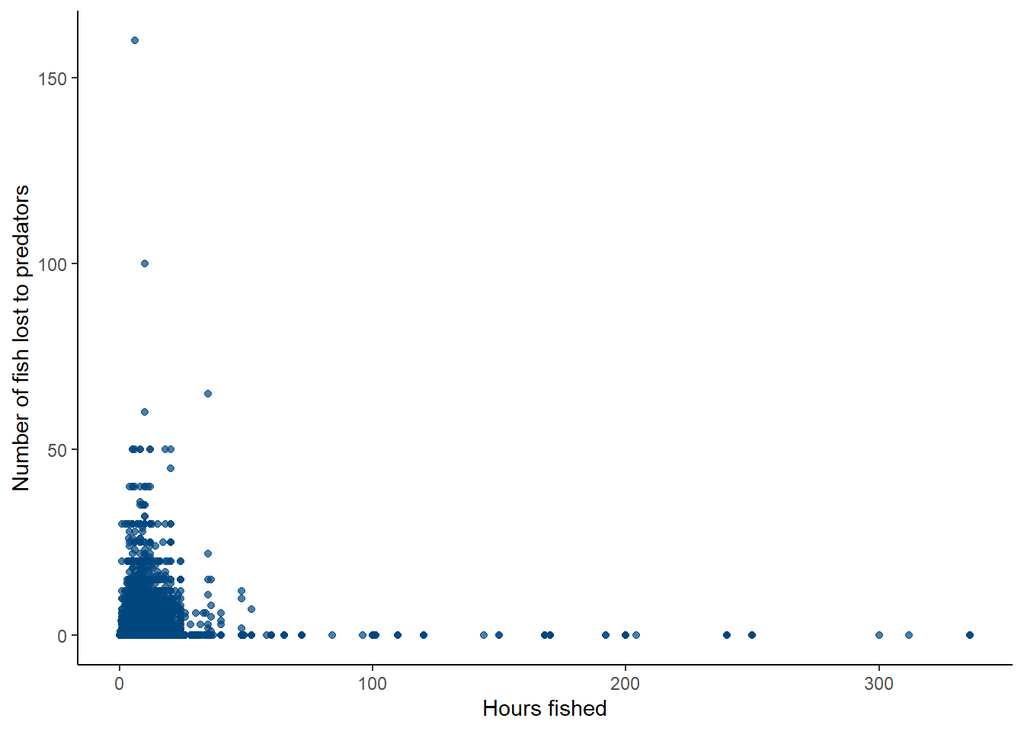

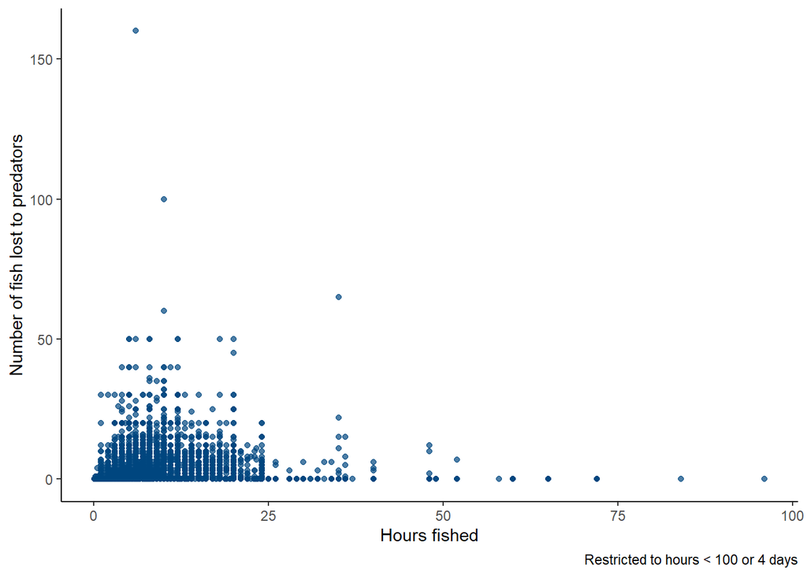

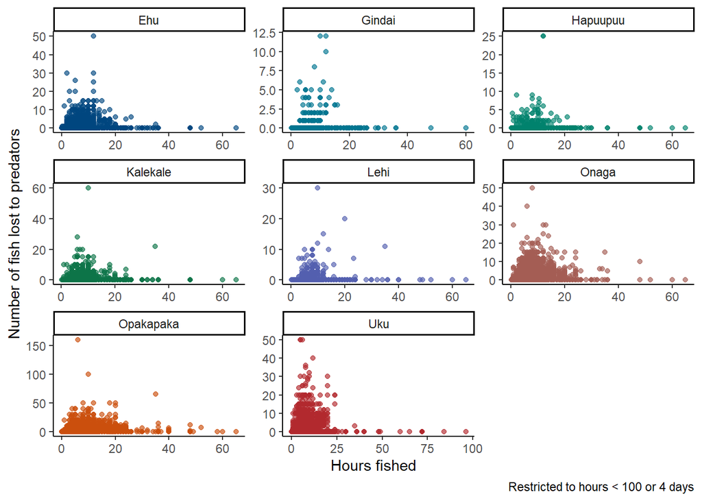

#### Hooks Used

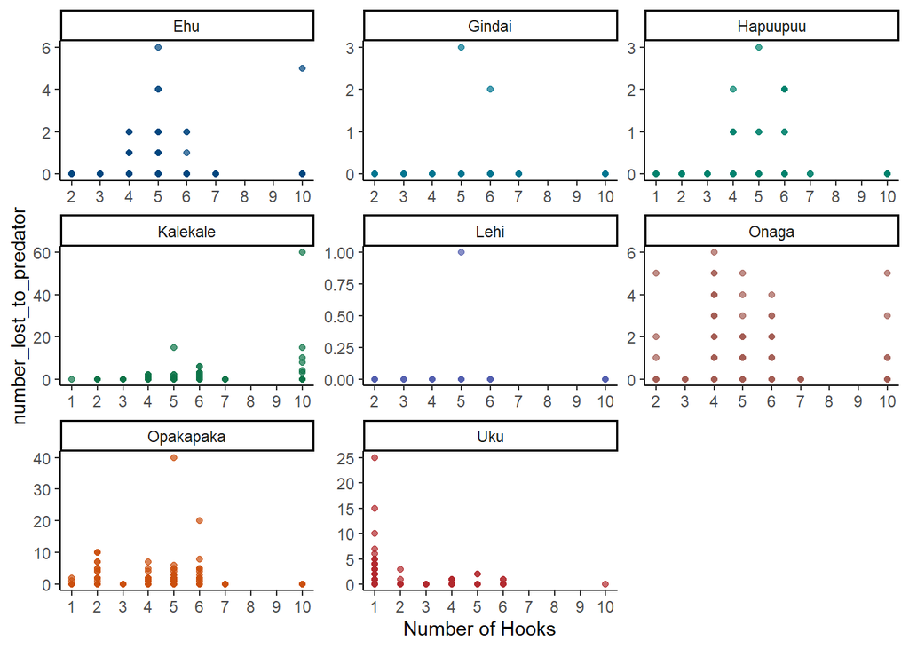

## Removing Some Zeros

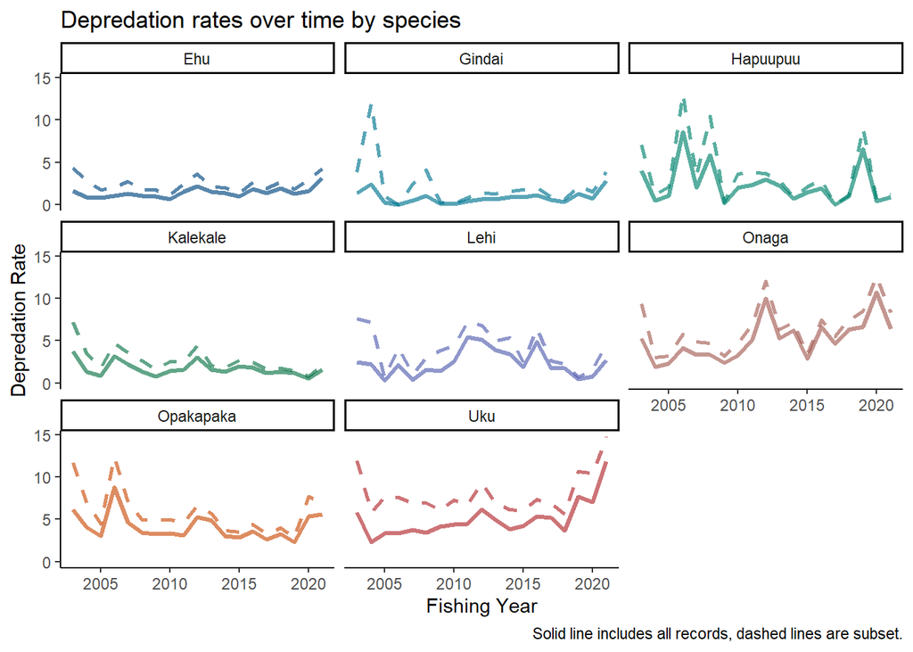

Total percent of catch lost to predation by species

| Species | Number Lost | Number Caught | Number Released | Percent Lost to Predation | Original Depredation Rate |
| --- | --- | --- | --- | --- | --- |
| Uku | 10608 | 126394 | 1428 | 7.66 | 4.95 |
| Onaga | 11427 | 166431 | 950 | 6.39 | 4.90 |
| Opakapaka | 23548 | 413771 | 8043 | 5.29 | 3.90 |
| Lehi | 533 | 12794 | 59 | 3.98 | 2.38 |
| Hapuupuu | 330 | 8804 | 19 | 3.61 | 2.32 |
| Kalekale | 1872 | 72682 | 883 | 2.48 | 1.66 |
| Ehu | 3205 | 127766 | 1643 | 2.42 | 1.45 |
| Gindai | 253 | 12258 | 84 | 2.01 | 0.96 |

#### By Location

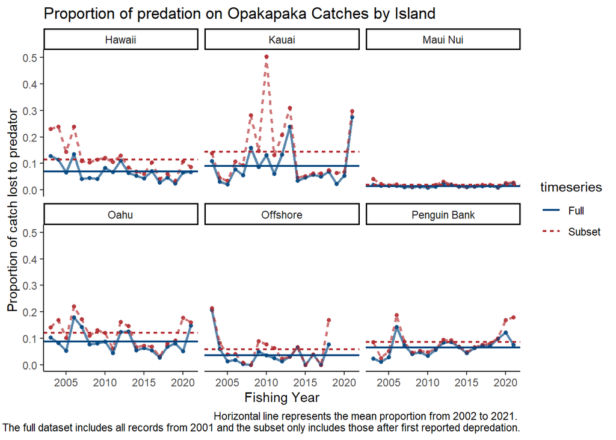

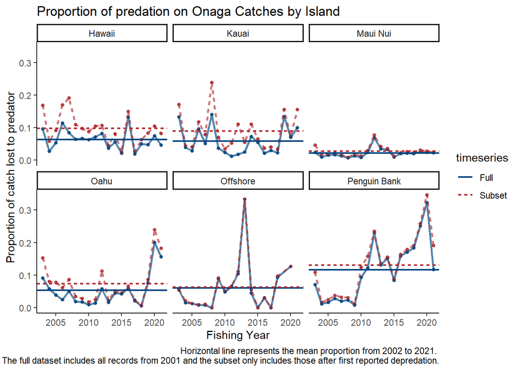

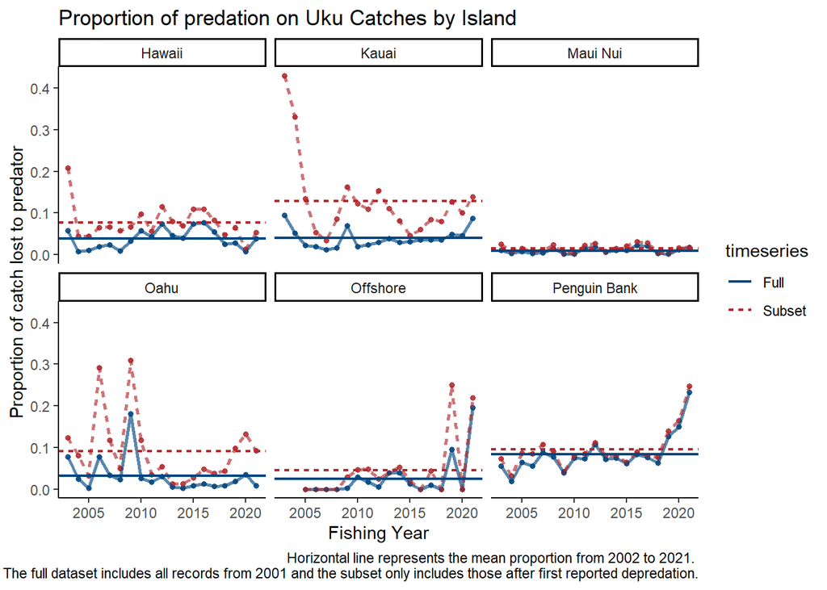